# Example of male students

Jan Vávra

2024-05-03

```r
library("MBCGLMMs")
library("colorspace")
library("mvtnorm")
library("splines")
library("MASS")
library("coda")
```

## Creating example dataset

Our example dataset consists of young male people observed repeatedly in their age span of 18-40 years. Each person has its id variable `i` and `j` denotes the number of observation for that particular person. The total number of observations $n_i$ per person differs and the times of examination are uniformly spread along the age years of 18-40.

We observe three outcomes:

- `income` the average income over last year (in artificial units),
- `ntrips` number of trips in the last year
- `satisfaction` the level of satisfaction (0=happy < 1=satisfied < 2=dissatisfied)

```r
source("C:/Users/jvavra/OneDrive - WU Wien/Documents/PhD/MBCGLMMs_examples/generate_student_example_data.R")
set.seed(31415)
n <- 2000
llist <- generate_student_example_data(n)
data <- llist$data
data$nogroup <- rep(0, dim(data)[1])
head(data[,c("i", "j", "g", "age", "income", "ntrips", "satisfaction")], 15)
```

```
##    i  j g      age    income ntrips satisfaction
## 1  1  1 2 18.33574  78.26589      4            1
## 2  1  2 2 19.46614  96.53933      0            1
## 3  1  3 2 22.38022 117.18257      1            0
## 4  1  4 2 23.72149 119.14538      1            0
## 5  1  5 2 26.51589 132.67795      5            1
## 6  1  6 2 28.45423 150.20632      8            0
## 7  1  7 2 31.00015 134.33201      3            0
## 8  1  8 2 34.27309 172.10387      0            2
## 9  1  9 2 36.27525 175.76842      7            1
## 10 1 10 2 37.05515 169.57596      4            0
## 11 1 11 2 39.72513 153.51558      7            0
## 12 2  1 2 18.23570  81.51344      1            2
## 13 2  2 2 21.66279  88.70070      2            2
## 14 2  3 2 23.43701 102.77982      0            0
## 15 2  4 2 25.96782 135.54990      0            0
```

```r
summary(as.factor(table(data$i))) # summary of total observation counts
```

```
##   8   9  10  11  12  13  14
## 711 745 384 120  29   8   3
```

```r
summary(data[,c("age", "income", "ntrips", "satisfaction")])
```

```
##       age            income           ntrips        satisfaction
##  Min.   :18.00   Min.   : 60.74   Min.   : 0.000   Min.   :0.0000
##  1st Qu.:22.96   1st Qu.:112.60   1st Qu.: 1.000   1st Qu.:0.0000
##  Median :28.99   Median :135.10   Median : 2.000   Median :1.0000
##  Mean   :29.00   Mean   :134.68   Mean   : 3.205   Mean   :0.9886
##  3rd Qu.:35.03   3rd Qu.:156.57   3rd Qu.: 4.000   3rd Qu.:2.0000
##  Max.   :40.00   Max.   :209.81   Max.   :38.000   Max.   :2.0000
```

## Plotting longitudinal data

### Numerical outcome - student income vs. age

In general there seems to be an increasing trend.

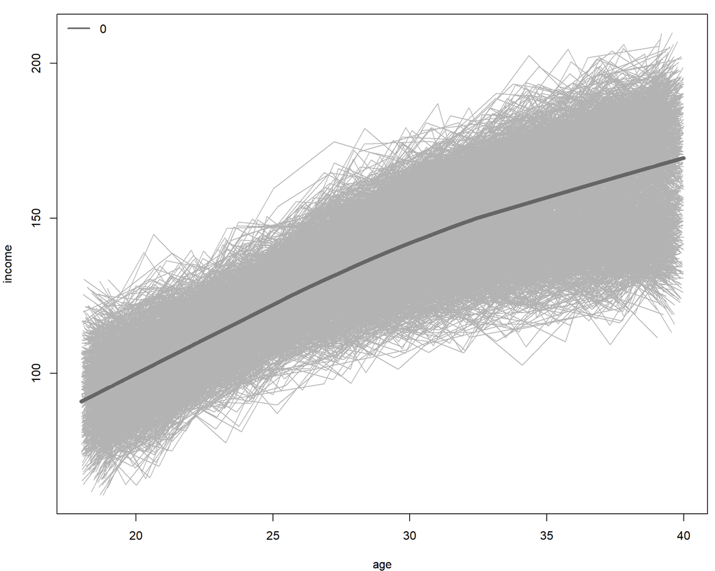

```r
par(mar=c(4,4,1,0.5))
plot.num_vs_x_grouped(data, "income", x="age", g="nogroup", legend_placement="topleft")
```

However, on closer look (having the true clustering variable `g` at disposal) there could be seen 2 to 3 groups of different evolution. One group clearly has slower income increase than the other.

Interpretation:

- group 1 (red): people who did not study at university start to earn money earlier;
- group 2+3 (green, blue): university degree helps these people to start their career with steeper increase of income. Hard-working ones (blue) have slightly higher income.

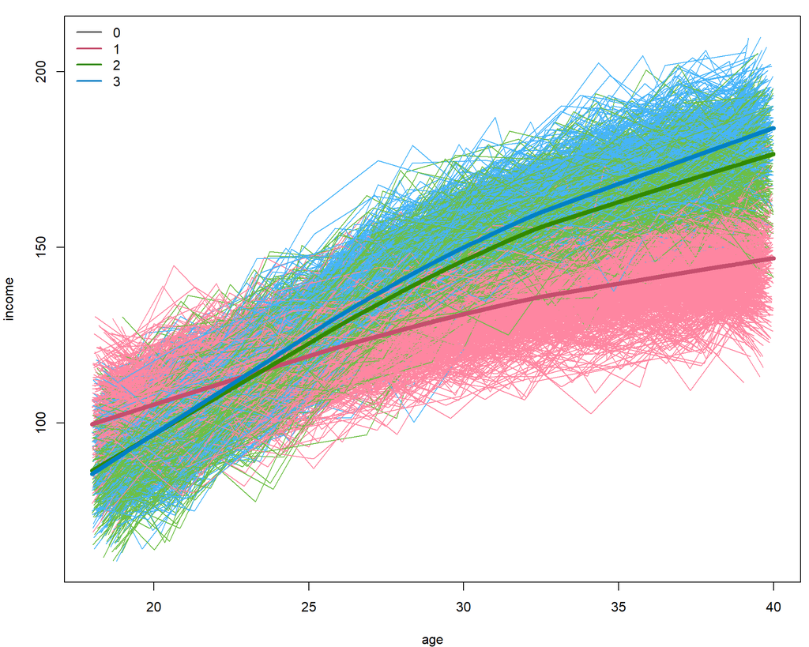

```r
par(mar=c(4,4,1,0.5))
plot.num_vs_x_grouped(data, "income", x="age", g="g", legend_placement="topleft")
```

### Count outcome - number of trips income vs. age

When young, people have plenty of time for going on trips. Then, as the university is studied and career is built, fewer trips are taken. Once you have a family more trips are taken.

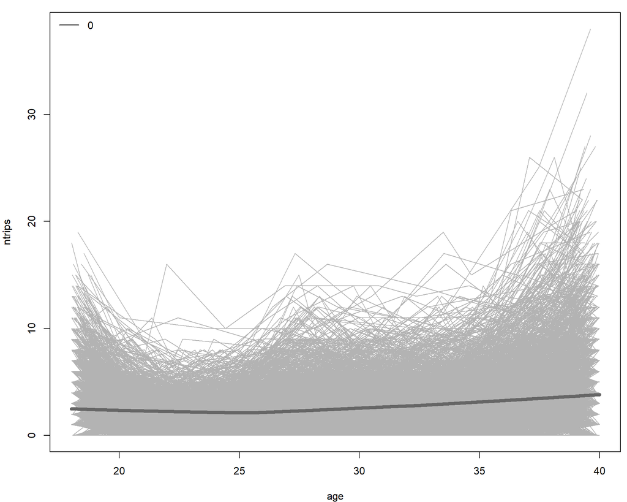

```r
par(mar=c(4,4,1,0.5))
data$log_ntrips <- log(data$ntrips+1)
plot.num_vs_x_grouped(data, "ntrips", x="age", g="nogroup", legend_placement="topleft")
```

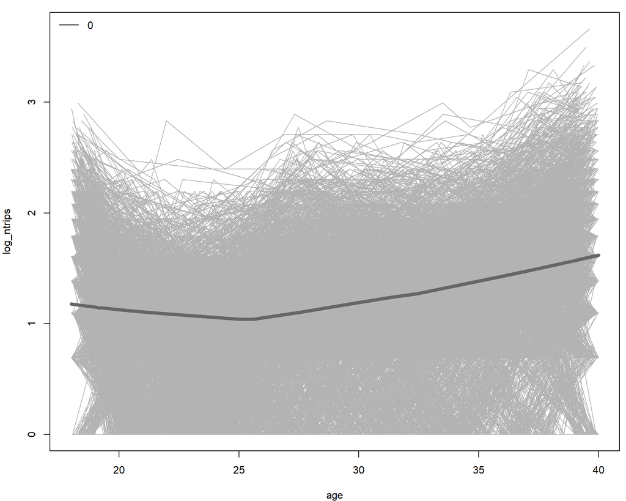

```r
plot.num_vs_x_grouped(data, "log_ntrips", x="age", g="nogroup", legend_placement="topleft")
```

However, on closer look (having the true clustering variable `g` at disposal) there could be seen 3 groups of different evolution.

Interpretation:

- group 1 (red): families earlier, but not many trips due to low income;
- group 2 (green): not many trips during studies, then high increase to enjoy, then less trips when starting a family, as the kids are older more trips;
- group 3 (blue): hard-workers, not many trips taken despite having high income, if some trip taken then probably long and expensive.

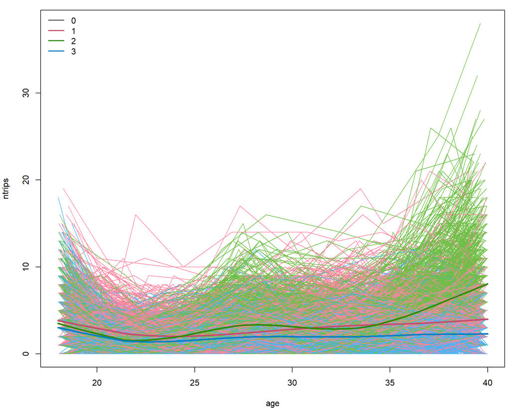

```r
par(mar=c(4,4,1,0.5))
COL <- rainbow_hcl(3, c = 80, l = 50)
plot.num_vs_x_grouped(data, "ntrips", x="age", g="g", legend_placement="topleft", add_lowess=FALSE)
for(g in 1:3){
  subdata <- data[data$g == g,]
  lines(lowess(exp(subdata$pred_poi) ~ subdata$age, f = 1/3), col = COL[g], lwd = 3)
}
```

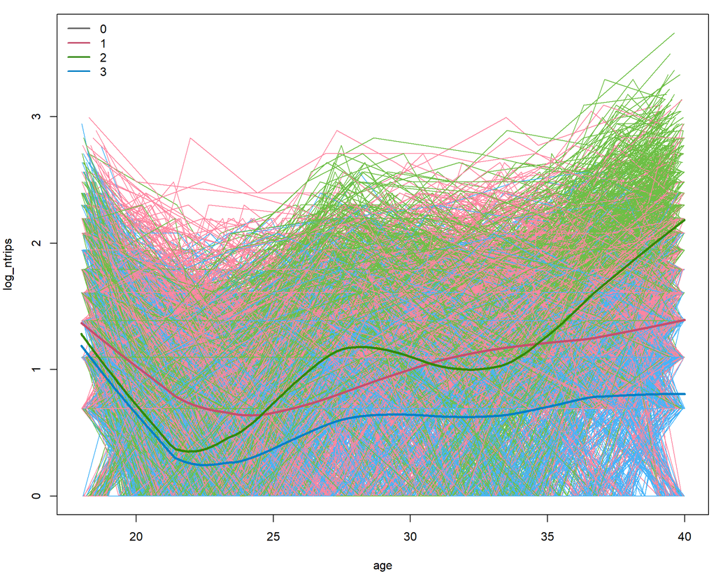

```r
plot.num_vs_x_grouped(data, "log_ntrips", x="age", g="g", legend_placement="topleft", add_lowess=FALSE)
for(g in 1:3){
  subdata <- data[data$g == g,]
  lines(lowess(subdata$pred_poi ~ subdata$age, f = 1/3), col = COL[g], lwd = 3)
}
```

### Ordinal outcome - level of satisfaction vs. age

Men were also asked about their own (dis)satisfaction level 0=happy < 1=satisfied < 2=dissatisfied.

Interpretation:

- group 1 (red): no clear evolution in time,
- group 2 (green): dissatisfied during studies but once finished they enjoy life (with high income),
- group 3 (blue): hard-workers who spent too much time working and not relaxing.

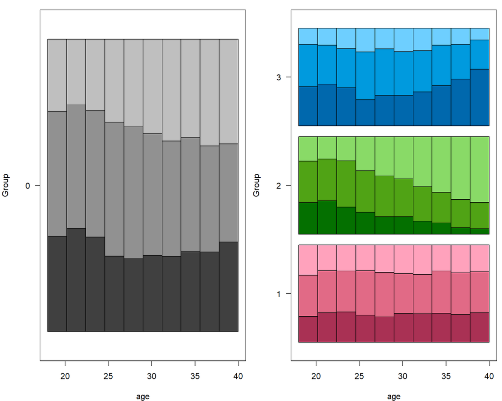

```r
par(mfrow = c(1,2), mar=c(4,4,1,0.5))
plot.cat_vs_x_grouped(data, "satisfaction", x="age", g="nogroup")
plot.cat_vs_x_grouped(data, "satisfaction", x="age", g="g")
```

The question is whether we are able to discover these latent groups from the available data: `i`, `age`, `income`, `ntrips`, `satisfaction`.

## Preparation for the estimation

```r
# splines
degree <- 2
knots <- c(18, 20, 25, 30, 35, 40)
inner <- knots[-c(1, length(knots))]
bound <- knots[c(1, length(knots))]
splB <- bs(data$age, knots = inner, Boundary.knots = bound,
           degree = degree, intercept = FALSE)
spldim <- dim(splB)[2]
bsnames <- paste0("bs",1:spldim)
data[,bsnames] <- splB

# outcomes and regressors to be used
Nums <- "income"
Pois <- "ntrips"
Bins <- c()
Ords <- "satisfaction"
Cats <- c()
Ys <- c(Nums, Pois, Bins, Ords, Cats)
Id <- "i"
Y <- data[,c(Id, Ys)]
X <- data[,c(Id, "age", paste0("bs",1:spldim))]
Formula1 <- Formula2 <- list()
for(y in Ys){
  # Formula1 = group-specific linear trends
  Formula1[[y]] <- list()
  Formula1[[y]]$fixed <- as.formula("~ 1")
  Formula1[[y]]$group <- as.formula("~ age")
  Formula1[[y]]$random <- as.formula("~ 1")
  Formula1[[y]]$offset <- ""

  # Formula2 = group-specific spline curves
  Formula2[[y]] <- list()
  Formula2[[y]]$fixed <- as.formula("~ 1")
  Formula2[[y]]$group <- as.formula(paste0("~ ", paste(bsnames, collapse = " + ")))
  Formula2[[y]]$random <- as.formula("~ 1")
  Formula2[[y]]$offset <- ""
}

# Group-specificity of other model parameters
spec <- c(T, T, F, F, F)
names(spec) <- c("tau_num", "c_ord", "InvSigma", "InvQ", "naY")
```

## Sampling MCMC chains for linear trends

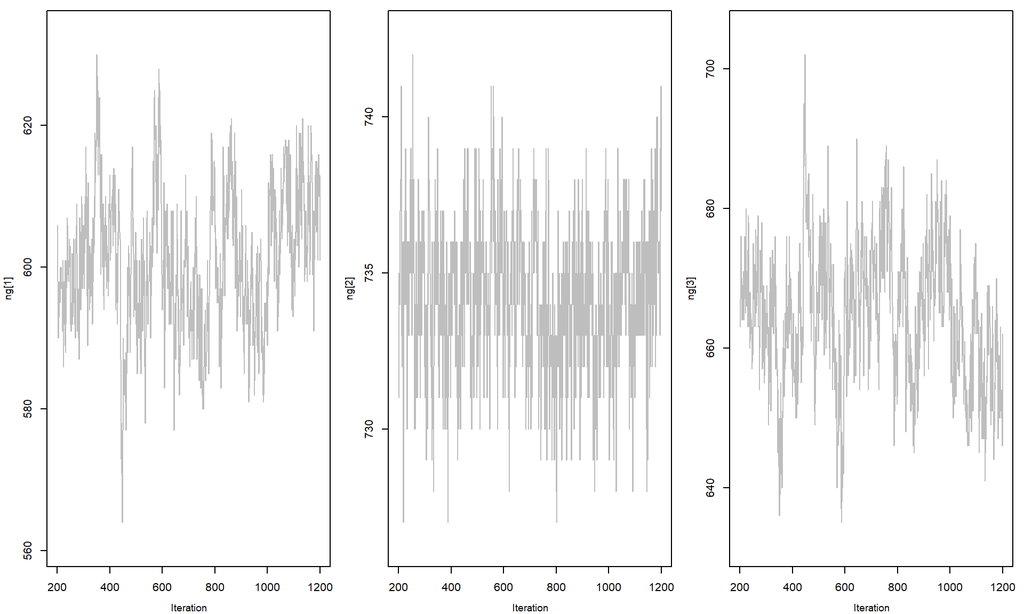

```r
set.seed(12345)
mcmc1 <- mcmc_MBC_GLMMs(Y = Y, X = X, G = 3, spec = spec,
                        Nums = Nums, Pois = Pois, Bins = Bins, Ords = Ords, Cats = Cats,
                        Id = Id, Formula = Formula1,
                        M = 1000, B = 200, Nchains = 1)
# preserve the interpretation of cluster labels by permuting cluster-specific parameters
perm <- list()
perm[[1]] <- c(2, 3, 1)
mcmc1 <- PermuteClusterSpec(mcmc1, perm, restricted = FALSE)

plot.traceplots_param(mcmc1, "ng")
```

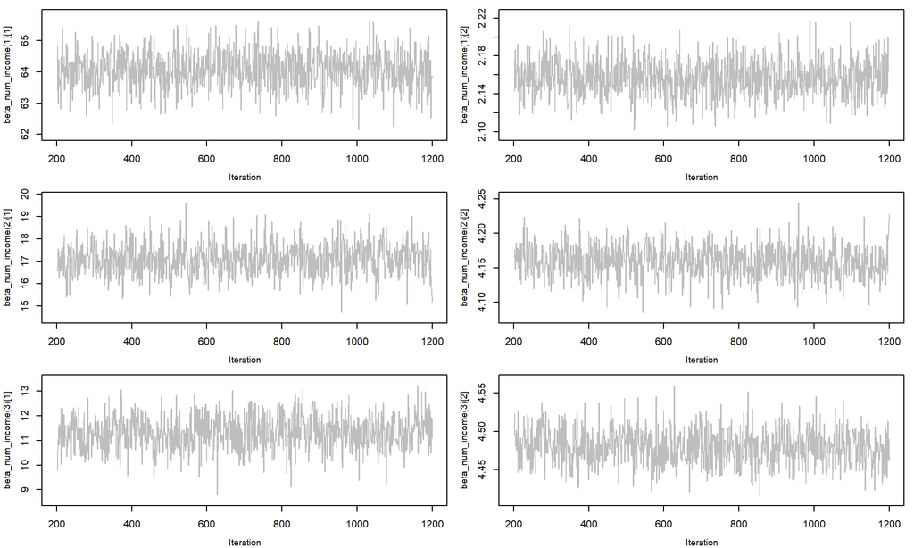

```r
plot.traceplots_param(mcmc1, "beta_num", thin = 1, ChainsToPlot = 1)
```

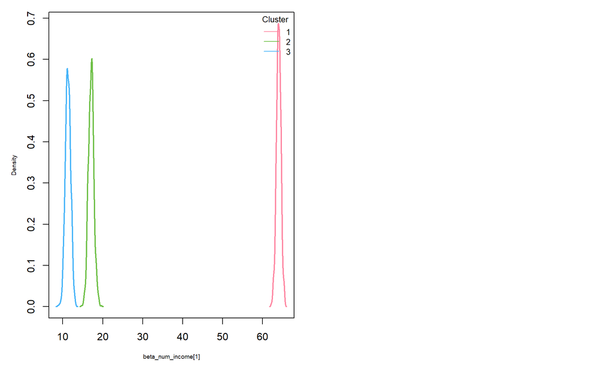

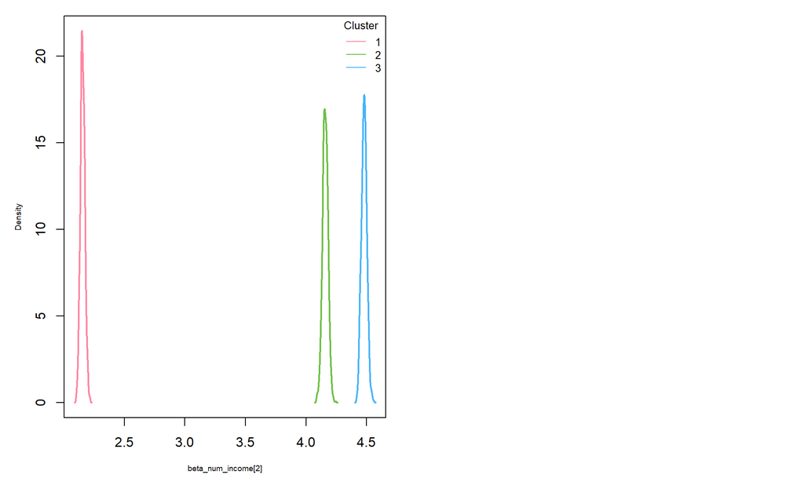

```r
plot.clusters_kerneldensity_param(mcmc1, "beta_num")
```

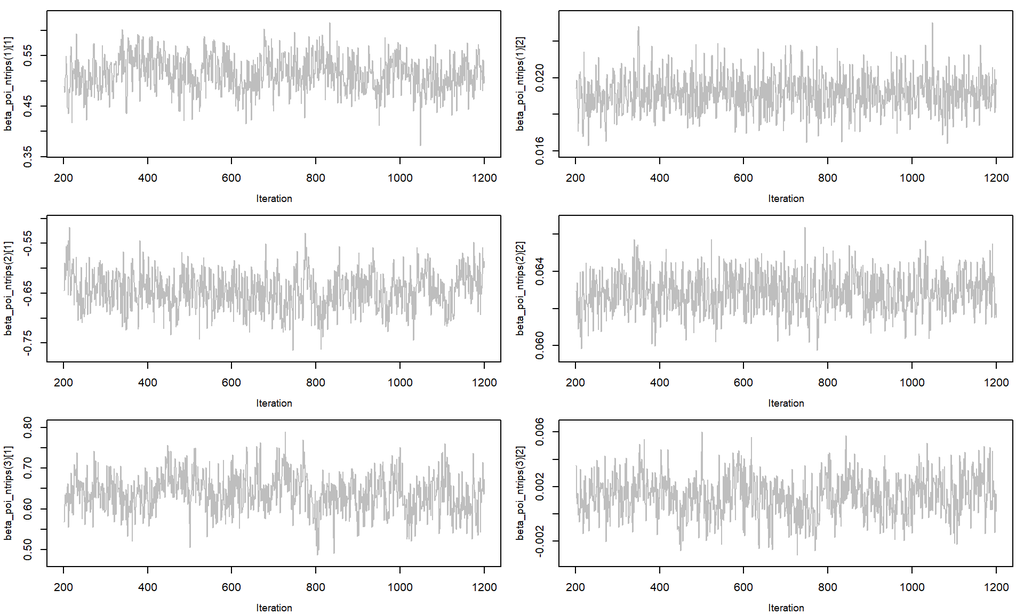

```r
plot.traceplots_param(mcmc1, "beta_poi", thin = 1, ChainsToPlot = 1)
```

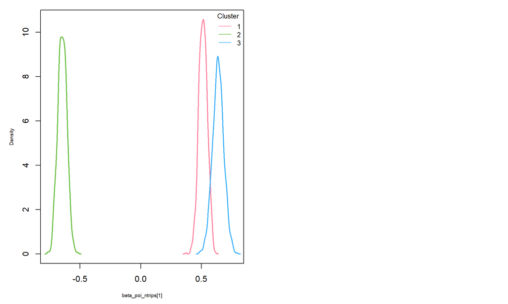

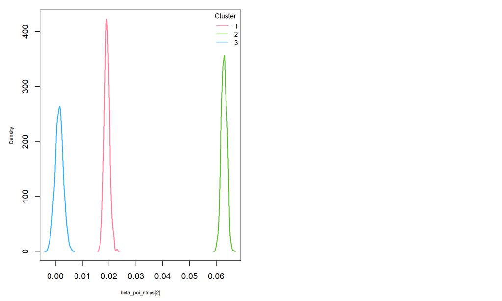

```r
plot.clusters_kerneldensity_param(mcmc1, "beta_poi")
```

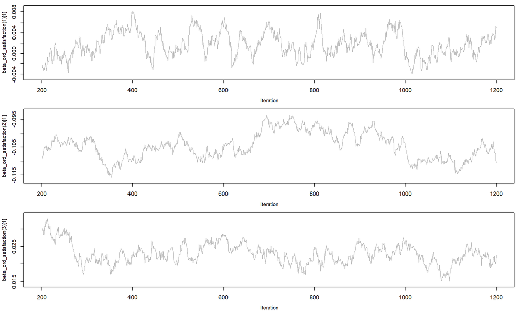

```r
plot.traceplots_param(mcmc1, "beta_ord", thin = 1, ChainsToPlot = 1)
```

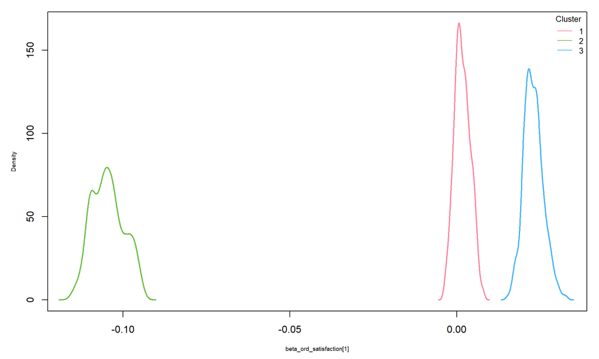

```r
plot.clusters_kerneldensity_param(mcmc1, "beta_ord")
```

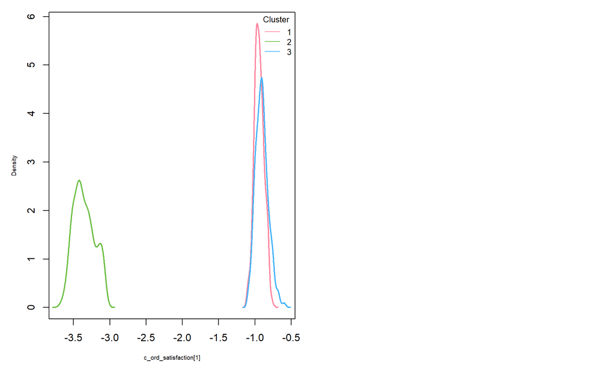

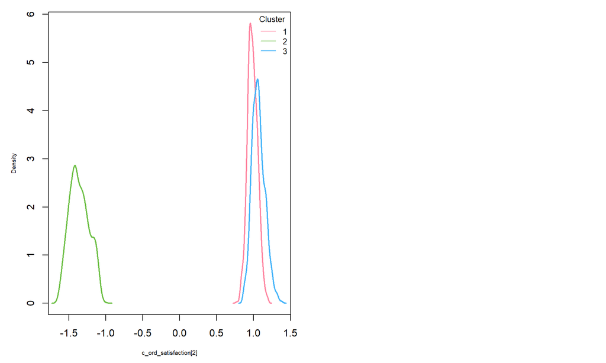

```r
plot.clusters_kerneldensity_param(mcmc1, "c_ord")
```

### Clustering based on sampled U values

```r
data <- clusteringU(mcmc1, data, Id = Id, threshold = 0.5)
data1 <- data[data$j==1, ]
# Confusion matrix for the first sampled chain
table(data1$clustering1, data1$g)
```

```
##
##       1   2   3
##   1 735   0   1
##   2   3 625  31
##   3   1  28 576
```

```r
# transform the outputs into coda format
codamcmc1 <- FromMatrixtoCoda(mcmc1)
sumcodamcmc1 <- summary(codamcmc1)
# coda summaries
sumcodamcmc1$statistics[grep("beta_num", rownames(sumcodamcmc1$statistics)), ]
```

```
##                            Mean         SD     Naive SE Time-series SE
## beta_num_income(1)[1] 64.072630 0.56914071 0.0179978094   0.0179978094
## beta_num_income(1)[2]  2.156815 0.01877835 0.0005938235   0.0005938235
## beta_num_income(2)[1] 17.108042 0.68778214 0.0217495811   0.0281610370
## beta_num_income(2)[2]  4.159237 0.02273995 0.0007191005   0.0008745589
## beta_num_income(3)[1] 11.315145 0.66768876 0.0211141725   0.0271934479
## beta_num_income(3)[2]  4.480076 0.02244047 0.0007096301   0.0009324128
```

```r
sumcodamcmc1$quantiles[grep("beta_num", rownames(sumcodamcmc1$quantiles)), ]
```

```
##                            2.5%       25%       50%       75%     97.5%
## beta_num_income(1)[1] 62.837643 63.716485 64.079177 64.463410 65.185272
## beta_num_income(1)[2]  2.120762  2.144763  2.155980  2.169555  2.195793
## beta_num_income(2)[1] 15.799359 16.661639 17.125911 17.540177 18.529497
## beta_num_income(2)[2]  4.113706  4.144515  4.159112  4.174835  4.203866
## beta_num_income(3)[1] 10.030776 10.875905 11.307071 11.769020 12.600480
## beta_num_income(3)[2]  4.437451  4.464705  4.480404  4.494730  4.523356
```

```r
sumcodamcmc1$statistics[grep("beta_poi", rownames(sumcodamcmc1$statistics)), ]
```

```
##                               Mean           SD     Naive SE Time-series SE
## beta_poi_ntrips(1)[1]  0.514279997 0.0350619607 1.108757e-03   2.711537e-03
## beta_poi_ntrips(1)[2]  0.019178602 0.0009880369 3.124447e-05   3.023556e-05
## beta_poi_ntrips(2)[1] -0.645510387 0.0372892637 1.179190e-03   2.725934e-03
## beta_poi_ntrips(2)[2]  0.062903278 0.0010432885 3.299168e-05   4.528045e-05
## beta_poi_ntrips(3)[1]  0.638588904 0.0467552305 1.478530e-03   3.903200e-03
## beta_poi_ntrips(3)[2]  0.001340019 0.0015045760 4.757887e-05   9.169511e-05
```

```r
sumcodamcmc1$statistics[grep("beta_ord", rownames(sumcodamcmc1$statistics)), ]
```

```
##                                     Mean          SD     Naive SE Time-series SE
## beta_ord_satisfaction(1)[1]  0.001667867 0.002350407 7.432639e-05   0.0004096264
## beta_ord_satisfaction(2)[1] -0.104548431 0.004796955 1.516930e-04   0.0017397690
## beta_ord_satisfaction(3)[1]  0.022931745 0.002924813 9.249071e-05   0.0006103830
```

```r
sumcodamcmc1$statistics[grep("c_ord", rownames(sumcodamcmc1$statistics)), ]
```

```
##                                Mean         SD    Naive SE Time-series SE
## c_ord_satisfaction(1)[1] -0.9399464 0.06708918 0.002121546     0.01138430
## c_ord_satisfaction(1)[2]  0.9867346 0.06774206 0.002142192     0.01020392
## c_ord_satisfaction(2)[1] -3.3545742 0.14565036 0.004605869     0.05045089
## c_ord_satisfaction(2)[2] -1.3594056 0.13301714 0.004206371     0.03850037
## c_ord_satisfaction(3)[1] -0.9031684 0.08867769 0.002804235     0.01563668
## c_ord_satisfaction(3)[2]  1.0665063 0.08862080 0.002802436     0.01785990
```

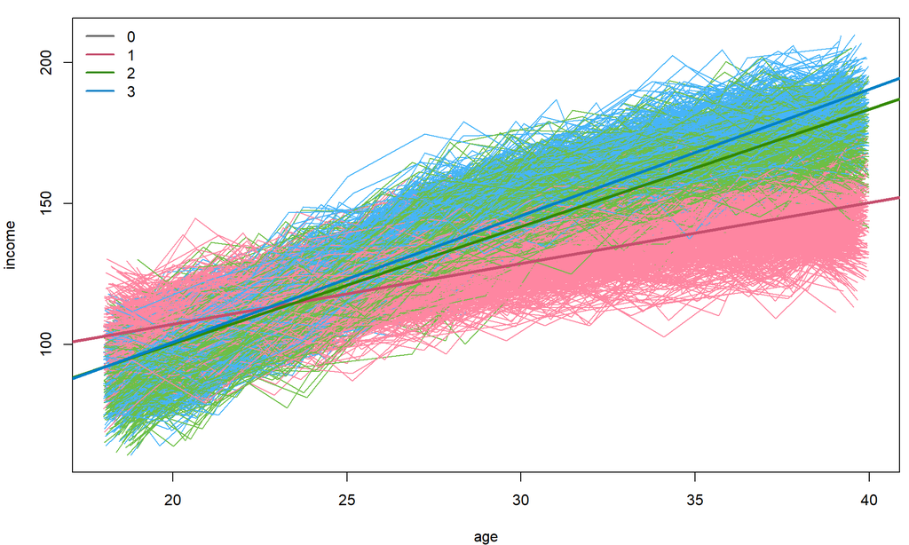

```r
par(mar=c(4,4,1,0.5))
plot.num_vs_x_grouped(data, "income", x="age", g="clustering1", legend_placement="topleft", add_lowess = FALSE)
for(g in 1:3){
  abline(a = sumcodamcmc1$statistics[paste0("beta_num_income(",g,")[1]"), "Mean"],
         b = sumcodamcmc1$statistics[paste0("beta_num_income(",g,")[2]"), "Mean"],
         col = COL[g], lwd = 3)
}
```

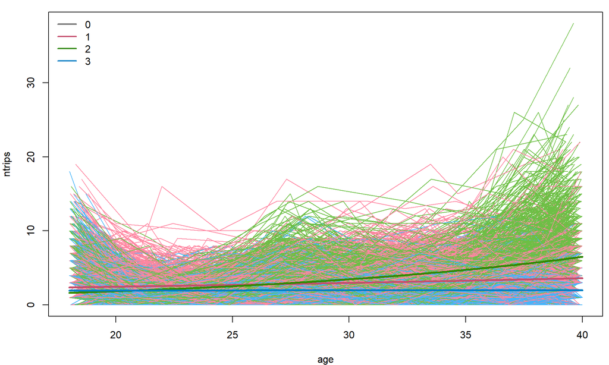

```r
par(mar=c(4,4,1,0.5))
plot.num_vs_x_grouped(data, "ntrips", x="age", g="clustering1", legend_placement="topleft", add_lowess = FALSE)
age_grid <- seq(18, 40, by = 0.1)
for(g in 1:3){
  lines(x = age_grid,
        y = exp(sumcodamcmc1$statistics[paste0("beta_poi_ntrips(",g,")[2]"), "Mean"] * age_grid + sumcodamcmc1$statistics[paste0("beta_poi_ntrips(",g,")[1]"), "Mean"]),
        col = COL[g], lwd = 3)
}
```

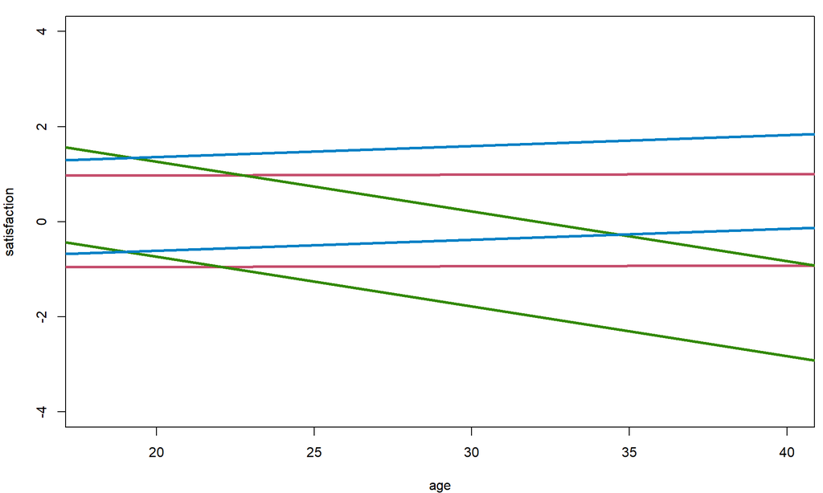

```r
par(mar=c(4,4,1,0.5))
plot(0,0,type="n", xlim = range(data$age), ylim = c(-4, 4), xlab = "age", ylab = "satisfaction")
for(g in 1:3){
  for(l in 1:2){
    abline(a = -sumcodamcmc1$statistics[paste0("c_ord_satisfaction(",g,")[", l, "]"), "Mean"],
           b = sumcodamcmc1$statistics[paste0("beta_ord_satisfaction(",g,")[1]"), "Mean"],
           col = COL[g], lwd = 3)
  }
}
```

## Sampling MCMC chains for spline trends

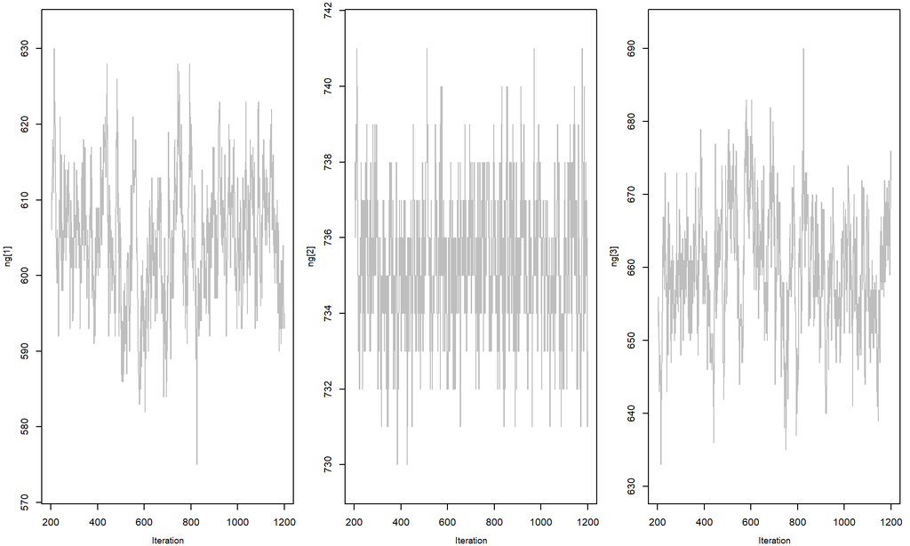

```r
set.seed(12345)
mcmc2 <- mcmc_MBC_GLMMs(Y = Y, X = X, G = 3, spec = spec,
                        Nums = Nums, Pois = Pois, Bins = Bins, Ords = Ords, Cats = Cats,
                        Id = Id, Formula = Formula2,
                        M = 1000, B = 200, Nchains = 1)
# preserve the interpretation of cluster labels by permuting cluster-specific parameters
perm <- list()
perm[[1]] <- c(2, 3, 1)
mcmc2 <- PermuteClusterSpec(mcmc2, perm, restricted = FALSE)
plot.traceplots_param(mcmc2, "ng")
```

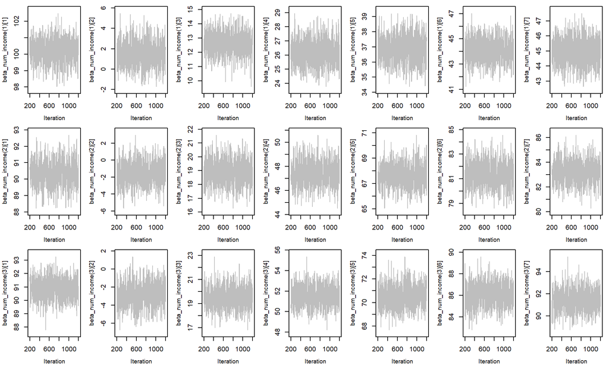

```r
plot.traceplots_param(mcmc2, "beta_num", thin = 1, ChainsToPlot = 1)
```

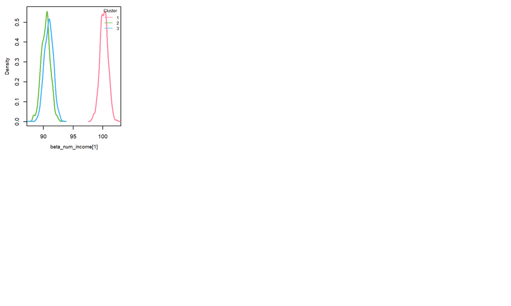

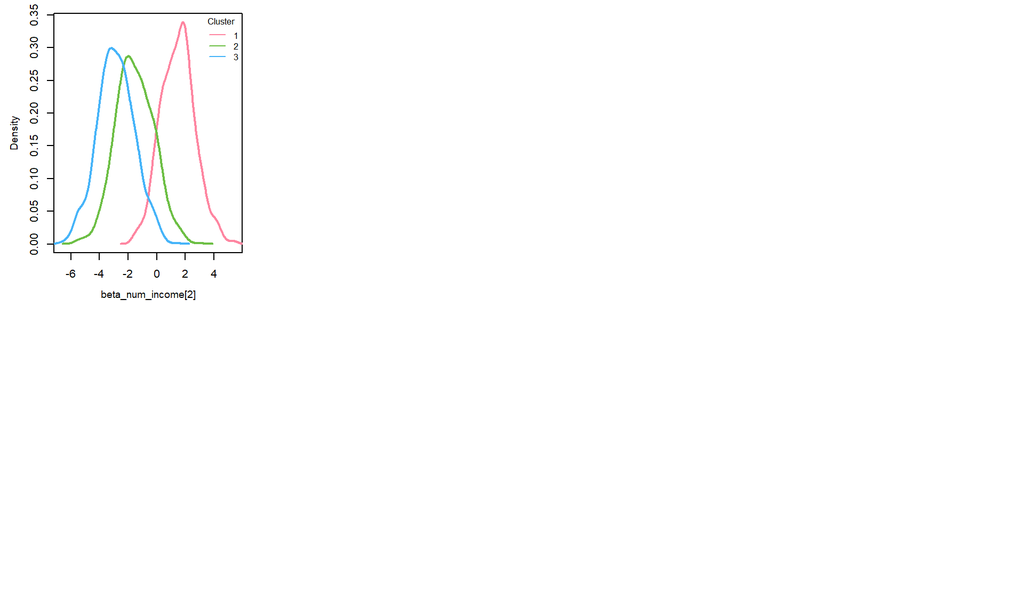

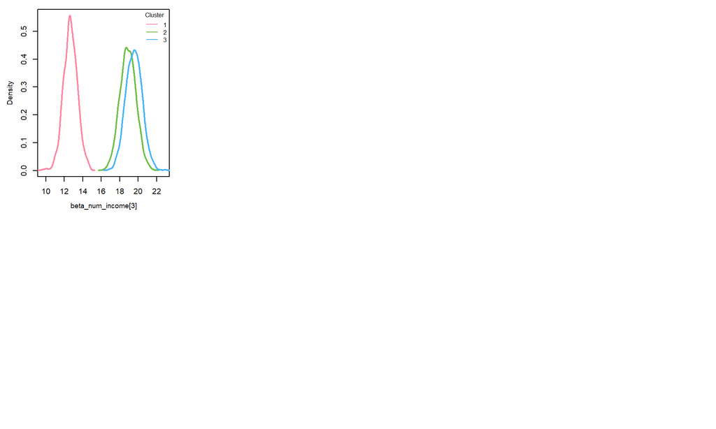

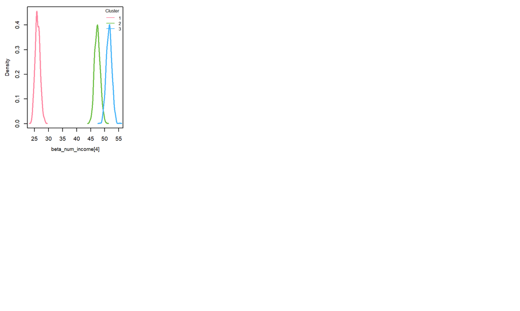

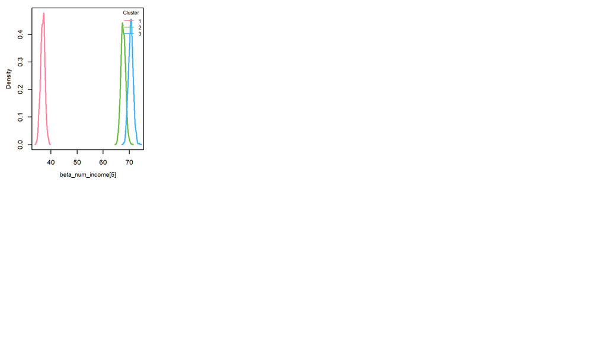

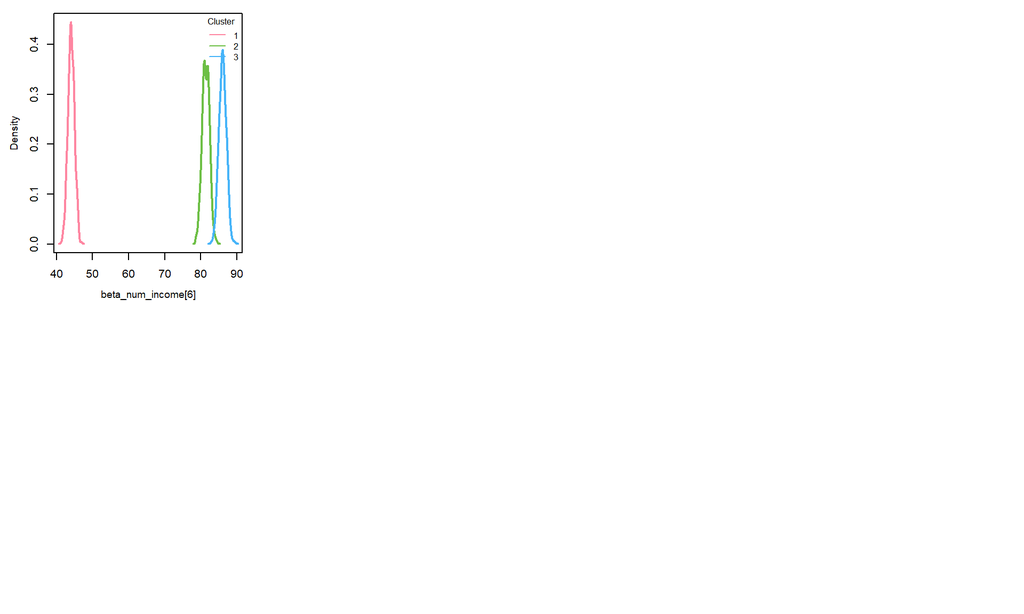

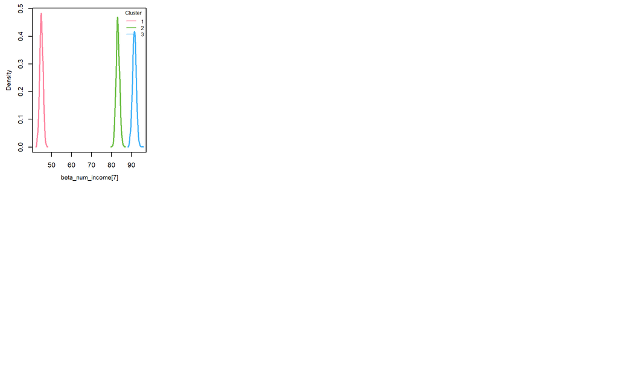

```r
plot.clusters_kerneldensity_param(mcmc2, "beta_num")
```

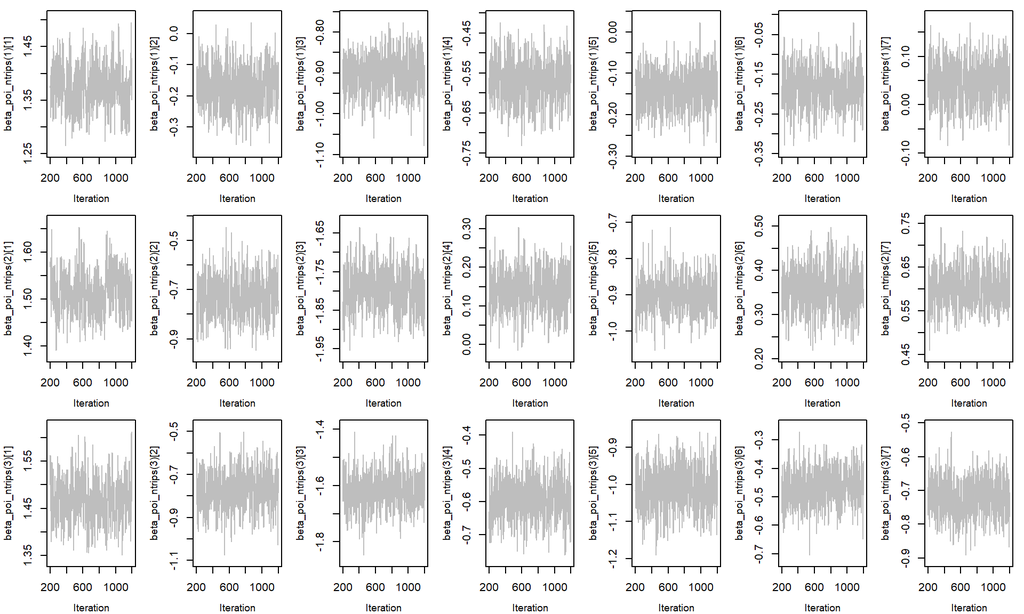

```r
plot.traceplots_param(mcmc2, "beta_poi", thin = 1, ChainsToPlot = 1)
```